# Lab 3 solution

Read and thin polygon data

```r
library(maptools)
xx <- readShapeSpatial("../data/australia/region.shp")
xxx <- thinnedSpatialPoly(as(xx, "SpatialPolygons"), tolerance = 0.1, minarea = 0.001,
    topologyPreserve = TRUE)
```

```
## rgeos version: 0.3-2, (SVN revision 413M)
##  GEOS runtime version: 3.3.3-CAPI-1.7.4
##  Polygon checking: TRUE
```

Function to extract polygons

```r
extractPolygons <- function(shapes) {
    require(plyr)

    dframe <- ldply(1:length(shapes@polygons), function(i) {
        ob <- shapes@polygons[[i]]@Polygons
        dframe <- ldply(1:length(ob), function(j) {
            x <- ob[[j]]
            co <- x@coords
            data.frame(co, order = 1:nrow(co), group = j)
        })
        dframe$region <- i
        dframe
    })
    # construct a group variable from both group and polygon:
    dframe$group <- interaction(dframe$region, dframe$group)

    dframe
}
```

Run function on Australia data and Africa data

```r
oz <- extractPolygons(xxx)
```

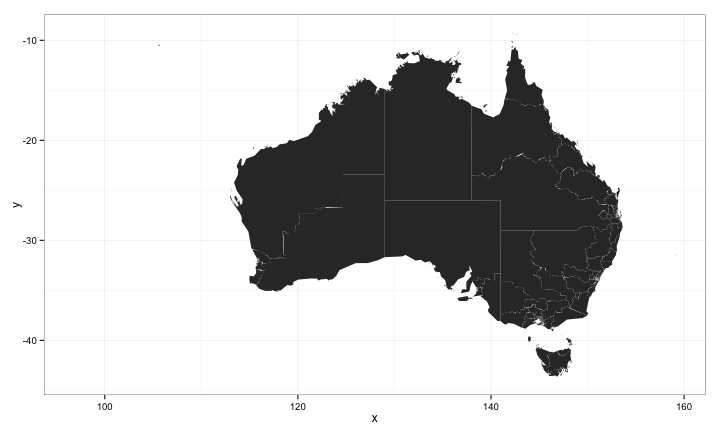

```r
library(ggplot2)
qplot(x, y, order = order, group = group, data = oz, geom = "polygon") + theme_bw()
```

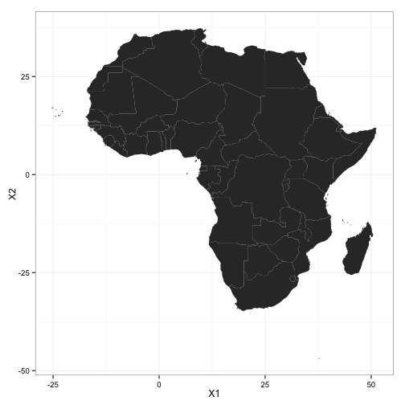

```r
africa <- extractPolygons(readShapeSpatial("../data/Africa/Africa.shp"))
qplot(X1, X2, order = order, group = group, data = africa, geom = "polygon") +
    theme_bw()
```

Alternative function - winner of the shortest, best solution!

library(plyr) extractPolygons2 <- function(d.d) { ldply(d.d@polygons, function(x) fortify(x)) }

but fortify function doesn't exist for me.

Color by the area of the electoral district

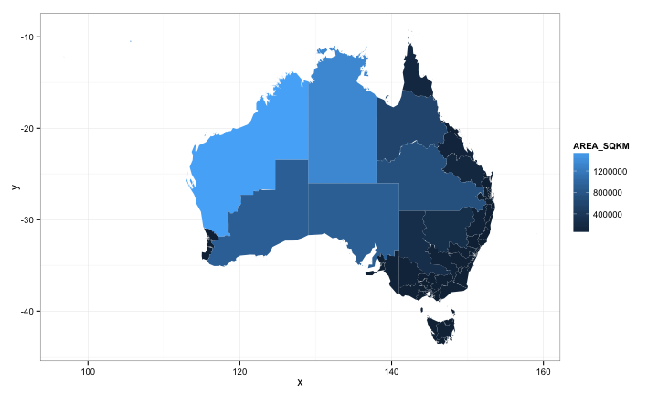

```r
xx@data$elec_id <- 1:150
oz_all <- merge(oz, xx@data, by.x = "region", by.y = "elec_id")
qplot(x, y, order = order, group = group, data = oz_all, geom = "polygon", fill = AREA_SQKM) +
    theme_bw()
```

Add polling stations. Mistake was due to an extra “ to refer to inches in one of the text fields, because ”“ were used to enclose the variable values. The problem is likely to have occurred close to where it fails, at line 3914. To find the spot of the problem, I read the lines in close to this spot using skip to find that it occurred at line 3901, and then loaded the data into a text editor to remove the extra ”.

Other solutions, included opening in excel, and saving with tab delimiters instead of commas, and then removing the all the “”. This works because there are no tabs in the text fields, where it doesn't work to remove “” with commas as the delimiter, because there are commas in the text fields. Yet another solution involved doing all of this with regular expressions and substitutions which we will learn about soon.

One last thing was to remove polling stations that were not active this election - done in the plotting code belwo.

```r
oz_poll_stns <- read.csv("http://www.aec.gov.au/About_AEC/cea-notices/files/2013/prdelms.gaz.statics.130901.09.00.02.csv",
    stringsAsFactors = FALSE)
oz_poll_stns <- read.csv("../data/australia/polling-places.csv", stringsAsFactors = FALSE)
oz_poll_stns$Lat <- as.numeric(oz_poll_stns$Lat)
oz_poll_stns$Long <- as.numeric(oz_poll_stns$Long)
table(oz_poll_stns$StateAb)
```

```
##
##  ACT  NSW   NT  QLD   SA  TAS  VIC   WA
##   85 2740   50 1482  703  333 2062  811
```

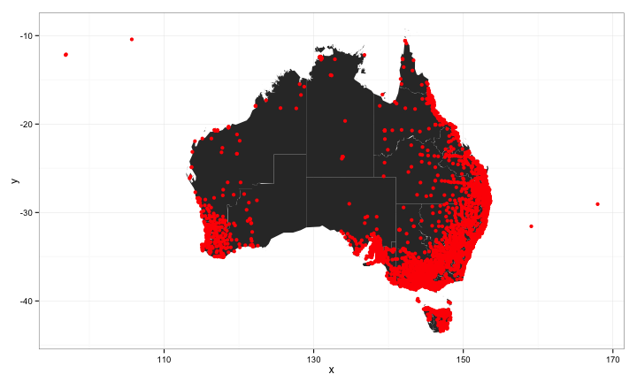

```r
ggplot() + geom_polygon(data = oz_all, aes(x = x, y = y, order = order, group = group)) +
    geom_point(data = subset(oz_poll_stns, Status != "Abolition"), aes(x = Long,
        y = Lat), colour = I("red")) + theme_bw()
```

The points in the ocean correspond to island territories. The strings of lines are along major highways, main centers of civilization is large tracts of the country. The empty areas along the east coast are mountains, some places the only part of Australia that see snow.